# Poisson Regression for Daily Total of Bike Counts

Sean Schilk

11/8/25

# 1 Introduction

We will model the daily counts (and proportion) of cyclists who entered and left the four bridges in New York City in this project.

## 1.1 Data and Variable Description

The daily total of bike counts was conducted monthly on the Brooklyn Bridge, Manhattan Bridge, Williamsburg Bridge, and Queensboro Bridge. To keep count of cyclists entering and leaving Queens, Manhattan, and Brooklyn via the East River Bridges. The Traffic Information Management System (TIMS) collects the count data. Each record represents the total number of cyclists per 24 hours at Brooklyn Bridge, Manhattan Bridge, Williamsburg Bridge, and Queensboro Bridge.

```r
# Load the data
bikes <- read.xlsx("https://sschilk.github.io/MySTA321/w09-AssignDataSet.xlsx")

bikes$Day <- as.Date(bikes$Day, origin = "1899-12-30")
bikes$Day <- weekdays(bikes$Day)

bikes$AvgTemp <- (bikes$HighTemp + bikes$LowTemp) / 2

bikes$binPrecip <- ifelse(bikes$Precipitation == 0, 0, 1)

head(bikes)
```

```
   Date       Day HighTemp LowTemp Precipitation ManhattanBridge Total AvgTemp
1 42826  Saturday     46.0      37          0.00            1446  5397   41.50
2 42827    Sunday     62.1      41          0.00            3943 13033   51.55
3 42828    Monday     63.0      50          0.03            4988 16325   56.50
4 42829   Tuesday     51.1      46          1.18            1913  6581   48.55
5 42830 Wednesday     63.0      46          0.00            5276 17991   54.50
6 42831  Thursday     48.9      41          0.73            1324  4896   44.95
  binPrecip
1         0
2         0
3         1
4         1
5         0
6         1
```

# 2 Possion Regression on Rates

This model is the “appropriateness model”. The bikes crossing the bridge are dependent on the **total** bike crossings, so we model the bridge rates that involve the total bike crossings.

```r
model.rates <- glm(ManhattanBridge ~ Day + AvgTemp + binPrecip, offset = log(Total),
                   family = poisson(link = "log"), data = bikes)

kable(summary(model.rates)$coef, caption = "Poisson regression on the rate of the bike totals")
```

Poisson regression on the rate of the bike totals

|  | Estimate | Std. Error | z value | Pr(>\|z\|) |
| --- | --- | --- | --- | --- |
| (Intercept) | -1.2941239 | 0.0226584 | -57.1145223 | 0.0000000 |
| DayMonday | 0.0385378 | 0.0100316 | 3.8416416 | 0.0001222 |
| DaySaturday | -0.0460262 | 0.0108544 | -4.2403335 | 0.0000223 |
| DaySunday | 0.0094561 | 0.0103562 | 0.9130864 | 0.3611971 |
| DayThursday | -0.0185708 | 0.0108760 | -1.7074953 | 0.0877300 |
| DayTuesday | 0.0044425 | 0.0107427 | 0.4135354 | 0.6792144 |
| DayWednesday | 0.0109419 | 0.0108145 | 1.0117767 | 0.3116448 |
| AvgTemp | 0.0009254 | 0.0003539 | 2.6151354 | 0.0089192 |
| binPrecip | -0.0065696 | 0.0068784 | -0.9551003 | 0.3395270 |

Using Friday as the reference category, the expected log rate of bike crossings was slightly higher on Monday and slightly lower on Saturday, while the other weekdays and Sunday did not differ significantly from Friday.

## 2.1 Extracting Dispersion Index

We use the regular Poisson regression model here to extract the dispersion parameter to decide which model (Quasi or regular Poisson) should be used as a working model.

```r
pois.model = glm(ManhattanBridge ~ Day + AvgTemp + binPrecip,
                 offset = log(Total), ,
                 family = poisson(link="log"), data =bikes)
## predicted y: yhat
yhat = pois.model$fitted.values
pearson.resid = (bikes$ManhattanBridge - yhat)/sqrt(yhat)
Pearson.disp = sum(pearson.resid^2)/pois.model$df.residual
##
Deviance.disp = (pois.model$deviance)/pois.model$df.residual
##
disp = cbind(Pearson.disp = Pearson.disp, Deviance.disp = Deviance.disp)
kable(disp, caption="Dispersion parameter", align = 'c')
```

Dispersion parameter

| Pearson.disp | Deviance.disp |
| --- | --- |
| 4.764617 | 4.80602 |

## 2.2 Quasi-Poisson Rate Model

This is the summary statistics of the Quasi-Poisson model.

```r
quasi.model = glm(ManhattanBridge ~ Day + AvgTemp + binPrecip, offset=log(Total) ,,
                 family = quasipoisson, data =bikes)
summary(quasi.model )
```

```
Call:
glm(formula = ManhattanBridge ~ Day + AvgTemp + binPrecip, family = quasipoisson,
    data = bikes, offset = log(Total))

Coefficients:
               Estimate Std. Error t value Pr(>|t|)
(Intercept)  -1.2941239  0.0494588 -26.166   <2e-16 ***
DayMonday     0.0385378  0.0218970   1.760   0.0930 .
DaySaturday  -0.0460262  0.0236930  -1.943   0.0656 .
DaySunday     0.0094561  0.0226055   0.418   0.6800
DayThursday  -0.0185708  0.0237402  -0.782   0.4428
DayTuesday    0.0044425  0.0234491   0.189   0.8516
DayWednesday  0.0109419  0.0236059   0.464   0.6478
AvgTemp       0.0009254  0.0007724   1.198   0.2442
binPrecip    -0.0065696  0.0150142  -0.438   0.6662
---
Signif. codes:  0 '***' 0.001 '**' 0.01 '*' 0.05 '.' 0.1 ' ' 1

(Dispersion parameter for quasipoisson family taken to be 4.764619)

    Null deviance: 196.23  on 29  degrees of freedom
Residual deviance: 100.93  on 21  degrees of freedom
AIC: NA

Number of Fisher Scoring iterations: 3
```

The estimated dispersion index is 4.76 based on the Pearson residuals.

The above model will be used as the final model. The interpretation of the regression coefficient of the Poisson model is not as straightforward as that in the linear regression models since the response variable in the model is at a log scale.

For example, the coefficient associated with binPrecip is -0.0065696. This is the estimated Poisson regression coefficient comparing precipitation to no precipitation, given the other variables are held constant in the model.The difference in the logs of totals is expected to be 0.0065696 units lower for precipitation compared to no precipitation while holding the other variables constant in the model.

## 2.3 Some Visual Comparisons

```r
DayFriday =  c(exp(-1.2941239), exp(-1.2941239+0.0009254))
```

Next, we make a visualization to show how the explanatory variables in the final working model affect the actual number of bridge crossings on bikes.

To this end, we classify observations into the following groups defined by day and precipitation:

- **bikes.f0** = Friday, with no precipitation
- **bikes.m0** = Monday, with no precipitation
- **bikes.tu0** = Tuesday, with no precipitation
- **bikes.w0** = Wednesday, with no precipitation
- **bikes.th0** = Thursday, with no precipitation
- **bikes.sa0** = Saturday, with no precipitation
- **bikes.su0** = Sunday, with no precipitation

Next We exponentiate the log total of bike crossings then make graphs to show the relationship between the number of cyclists who entered and left the bridge and the related days and precipitation.

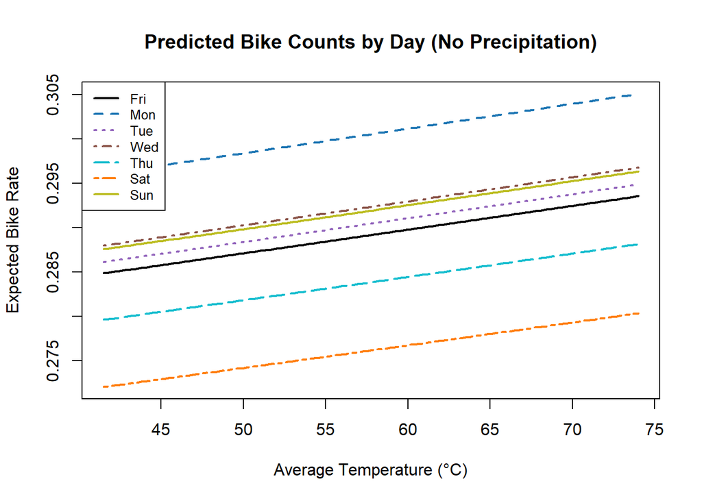

```r
AvgTemp <- seq(min(bikes$AvgTemp), max(bikes$AvgTemp), length = 100)

# Predicted log-counts (no precipitation)
bikes.f0  <- -1.2941239 + 0.0009254 * AvgTemp          # Friday (baseline)
bikes.m0  <- -1.2941239 + 0.0385378 + 0.0009254 * AvgTemp
bikes.tu0 <- -1.2941239 + 0.0044425 + 0.0009254 * AvgTemp
bikes.w0  <- -1.2941239 + 0.0109419 + 0.0009254 * AvgTemp
bikes.th0 <- -1.2941239 - 0.0185708 + 0.0009254 * AvgTemp
bikes.sa0 <- -1.2941239 - 0.0460262 + 0.0009254 * AvgTemp
bikes.su0 <- -1.2941239 + 0.0094561 + 0.0009254 * AvgTemp

# Compute expected counts
expected_counts <- exp(c(bikes.f0, bikes.m0, bikes.tu0, bikes.w0, bikes.th0, bikes.sa0, bikes.su0))

# Plot base line with correct range
plot(AvgTemp, exp(bikes.f0), type = "l", col = "black", lwd = 2,
     ylim = c(min(expected_counts), max(expected_counts)),
     xlab = "Average Temperature (°C)", ylab = "Expected Bike Rate",
     main = "Predicted Bike Counts by Day (No Precipitation)")

# Add other days
lines(AvgTemp, exp(bikes.m0),  col = "#1f77b4", lty = 2, lwd = 2)  # blue
lines(AvgTemp, exp(bikes.tu0), col = "#9467bd", lty = 3, lwd = 2)  # purple
lines(AvgTemp, exp(bikes.w0),  col = "#8c564b", lty = 4, lwd = 2)  # brown-gray
lines(AvgTemp, exp(bikes.th0), col = "#17becf", lty = 5, lwd = 2)  # teal
lines(AvgTemp, exp(bikes.sa0), col = "#ff7f0e", lty = 6, lwd = 2)  # orange
lines(AvgTemp, exp(bikes.su0), col = "#bcbd22", lty = 7, lwd = 2)  # yellow-ochre

# Add legend (matching colors)
legend("topleft",
       legend = c("Fri", "Mon", "Tue", "Wed", "Thu", "Sat", "Sun"),
       col = c("black", "#1f77b4", "#9467bd", "#8c564b", "#17becf", "#ff7f0e", "#bcbd22"),
       lty = 1:7, lwd = 2, cex = 0.8)
```

We can see the relationship between the number of cyclists who entered and left the bridge and the related days and precipitation:

- is positively associated (as average temp increases so does expected bike count).
- has Monday as the day where the bridge sees the highest expected bike count on any given temperature.

Now we look at a similar graph, this time accounting for days with precipitation.

To this end, we classify observations into the following groups defined by day and precipitation:

- **bikes.f1** = Friday, with precipitation
- **bikes.m1** = Monday, with precipitation
- **bikes.tu1** = Tuesday, with precipitation
- **bikes.w1** = Wednesday, with precipitation
- **bikes.th1** = Thursday, with precipitation
- **bikes.sa1** = Saturday, with precipitation
- **bikes.su1** = Sunday, with precipitation

Next We exponentiate the log total of bike crossings then make graphs to show the relationship between the number of cyclists who entered and left the bridge and the related days and precipitation.

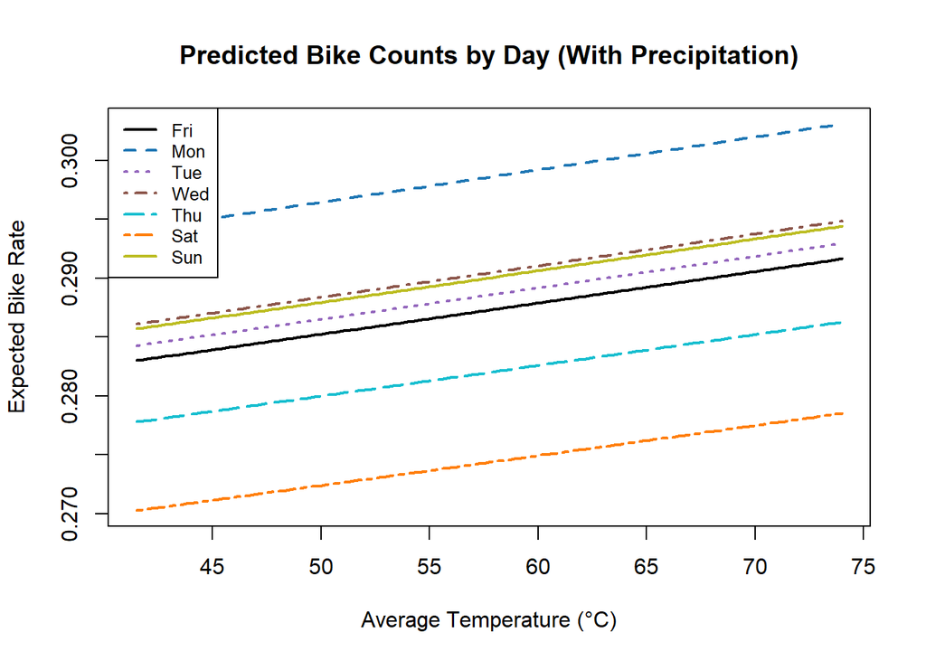

```r
# --- With precipitation (subtract coefficient) ---
bikes.f1  <- (-1.2941239 - 0.0065696) + 0.0009254 * AvgTemp
bikes.m1  <- (-1.2941239 + 0.0385378 - 0.0065696) + 0.0009254 * AvgTemp
bikes.tu1 <- (-1.2941239 + 0.0044425 - 0.0065696) + 0.0009254 * AvgTemp
bikes.w1  <- (-1.2941239 + 0.0109419 - 0.0065696) + 0.0009254 * AvgTemp
bikes.th1 <- (-1.2941239 - 0.0185708 - 0.0065696) + 0.0009254 * AvgTemp
bikes.sa1 <- (-1.2941239 - 0.0460262 - 0.0065696) + 0.0009254 * AvgTemp
bikes.su1 <- (-1.2941239 + 0.0094561 - 0.0065696) + 0.0009254 * AvgTemp

expected_counts_rain <- exp(c(bikes.f1, bikes.m1, bikes.tu1, bikes.w1, bikes.th1, bikes.sa1, bikes.su1))

plot(AvgTemp, exp(bikes.f1), type = "l", col = "black", lwd = 2,
     ylim = c(min(expected_counts_rain), max(expected_counts_rain)),
     xlab = "Average Temperature (°C)", ylab = "Expected Bike Rate",
     main = "Predicted Bike Counts by Day (With Precipitation)")
# Add other days
lines(AvgTemp, exp(bikes.m1),  col = "#1f77b4", lty = 2, lwd = 2)  # blue
lines(AvgTemp, exp(bikes.tu1), col = "#9467bd", lty = 3, lwd = 2)  # purple
lines(AvgTemp, exp(bikes.w1),  col = "#8c564b", lty = 4, lwd = 2)  # brown-gray
lines(AvgTemp, exp(bikes.th1), col = "#17becf", lty = 5, lwd = 2)  # teal
lines(AvgTemp, exp(bikes.sa1), col = "#ff7f0e", lty = 6, lwd = 2)  # orange
lines(AvgTemp, exp(bikes.su1), col = "#bcbd22", lty = 7, lwd = 2)  # yellow-ochre

# Add legend (matching colors)
legend("topleft",
       legend = c("Fri", "Mon", "Tue", "Wed", "Thu", "Sat", "Sun"),
       col = c("black", "#1f77b4", "#9467bd", "#8c564b", "#17becf", "#ff7f0e", "#bcbd22"),
       lty = 1:7, lwd = 2, cex = 0.8)
```

We can see the relationship between the number of cyclists who entered and left the bridge and the related days and precipitation is extremely similar to the previous graph, with the exception of the lines being slightly shifted downwards.

The conclusion we can draw is that with precipitation the expected bike count is a little lower than when there is no precipitation, which makes sense as less people would use their bike if it was raining.

# 3 Conclusions

Both the Poisson and Quasi-Poisson accounted for the rates-based data set.